# PhilaFire_PropensityScore

Ben Keel

2023-03-20

# Process

1. Load in results, as we captured in EDA.
2. Add open data covariates (OPA, ACS, Transfer Values) to those results.
3. Check mean (0 to 1) or of results for each test group.

# Tying the Sample Code to Our Own Data

https://sejdemyr.github.io/r-tutorials/statistics/tutorial8.html

## In the sample data:

Outcome variable of interest: standardized math score

Independent variable of interest: Catholic School y/n

Covariates:

- race_white: Is the student white (1) or not (0)?
- p5hmage: Mother’s age
- w3income: Family income
- p5numpla: Number of places the student has lived for at least 4 months
- w3momed_hsb: Is the mother’s education level high-school or below (1) or some college or more (0)?

## In our data:

Outcome variable of interest: Vacancy / Permits / Transfers

Independent variable of interest: Fire y/n

- Structure Fires Spatialized
  - address (ID)

Covariates:

- OPA Data (Tab Join)
  - address (ID)
  - building_code (categorical)
  - total_livable_area (continuous)
  - number_of_bedrooms (continuous)
  - number_of_bathrooms (continuous)
  - year_built (continuous)
  - quality_grade (ordinal)
  - owner occupied (t/f)
  - assessment price/sqft (continuous)
- ACS Data (Spatial Join)
  - Tract Average Income (continuous)
  - Tract average White racial makeup % (continuous)
- Neighborhoods (Spatial Join)
  - NHood Name
- Transfers Data (optional)
  - Sales price of 5 nearest buildings (continous)

# Data Imports

## Fire Data

### Cleaning

```r
# Creating geometry for the fires
dat <- structureFire

dat <- dat %>% drop_na("Longitude", "Latitude") %>%
  st_as_sf(coords = c("Longitude", "Latitude"), crs = "EPSG:4326")

# Cleaning the column names
dat <- clean_names(dat)

# Address string
dat <-
  dat %>% mutate(street_type = ifelse(street_type == 'AV', "AVE", street_type)) %>%
  unite(address, c('address_number', 'street_prefix', 'street_name', 'street_type'), sep = " ", remove = FALSE, na.rm=TRUE)

# Extracting quarter
dat <- dat %>% mutate(quarter = floor_date(alarm_date, unit="quarter"))

# Reducing columns
dat <- dat %>%
  dplyr::select(address, quarter, property_use, incident_number, number_of_exposures, incident_type, building_status, fire_spread, no_spread, code_description, geometry, alarm_date, cad_nature_code_description,
                minor_damage, significant_damage, heavy_damage, extreme_damage)

# Removing duplicates
dat <- dat[!duplicated(dat$incident_number),]

dat_boolean <- dat%>%
  st_drop_geometry%>%
  mutate(fire = 1)%>%
  dplyr::select(address, fire)

taney <- dat %>% filter(grepl("N TANEY", address))
```

## ACS Philadelphia

### Variables

```r
census_api_key("3c9540be1434ac4b38e6e55d60e8ee95909f2254", overwrite = TRUE)

#Variables
acs_variable_list.2020 <- load_variables(2020, #year
                                         "acs5", #five year ACS estimates
                                         cache = TRUE)

acs_variable_list.2016 <- load_variables(2016, #year
                                         "acs5", #five year ACS estimates
                                         cache = TRUE)
```

### Loading

```r
acs_vars <- c("B02001_001E", #Total Population
              "B02001_002E", #Total Population White Only
              "B19013_001E", #Median HH Income
              "B25002_001E", #Total Units
              "B25002_003E" #Total Vacant Units
              )

acsTractsPHL.2020 <- get_acs(geography = "tract",
                             year = 2020,
                             variables = acs_vars,
                             geometry = TRUE,
                             state = "PA",
                             county = "Philadelphia",
                             output = "wide")%>%
  rename(Total_Pop = B02001_001E,
         Total_Pop_WhiteOnly = B02001_002E,
         Med_Income = B19013_001E,
         Total_Vacant = B25002_003E,
         Total_Units = B25002_001E)%>%
  mutate(Perc_White = Total_Pop_WhiteOnly/Total_Pop,
         Perc_Vacant = Total_Vacant*100/Total_Units)%>%
  dplyr::select(-B02001_001M, -B02001_002M, -B19013_001M, -Total_Pop_WhiteOnly)%>%
  st_set_crs("EPSG:4326")
```

## OPA Data

### Loading

```r
# Reading the data
opa_dat <- read_csv("../Data/OpenDataPhilly-opa_properties_public.csv")

# Creating geometry for the properties
opa_dat <- opa_dat%>%
  drop_na(lat, lng)%>%
  st_as_sf(coords = c("lat", "lng"),
           crs = "EPSG:4326")
```

### Cleaning

```r
# Reducing columns
opa_ps <- opa_dat[!duplicated(opa_dat$location),] %>%
  dplyr::select(location, category_code, category_code_description, building_code, building_code_description, total_area, total_livable_area, market_value, mailing_street, number_of_bedrooms, number_of_bathrooms, number_stories, year_built, quality_grade)%>%
  filter(category_code == 1 | category_code == 2 | category_code == 3)%>%
  mutate(Price_Sqft = ifelse(is.na(total_livable_area) == FALSE & total_livable_area != 0, market_value / total_area, NA),
         quality_grade_mod = case_when(quality_grade == 1 ~ "E",
                                   quality_grade == 2 ~ "D",
                                   quality_grade == 3 ~ "C",
                                   quality_grade == 4 ~ "B",
                                   quality_grade == 5 ~ "A",
                                   quality_grade == 6 ~ "A+",
                                   TRUE ~ quality_grade,
                                   ))%>%
  rename(address = location)%>%
  mutate(condo = ifelse(grepl("CONDO", building_code_description) == TRUE, TRUE, FALSE),
        owner_occ = ifelse(condo == FALSE & category_code_description != "MULTI FAMILY",
                           ifelse(address == mailing_street, TRUE, FALSE),
                           NA))%>%
  filter(Price_Sqft < 100000)%>%
  dplyr::select(-quality_grade)

opa_ps$quality_grade_mod <- factor(opa_ps$quality_grade_mod, order = TRUE,
                               levels = c("A+", "A", "A-", "B+", "B", "B-", "C+", "C", "C-", "D+", "D", "D-", "E+", "E", "E-"))
```

## Neighborhoods

### Loading In

```r
#https://github.com/azavea/geo-data

nhoods <- st_read("../Data/Neighborhoods_Philadelphia.geojson")%>%
  st_set_crs("EPSG:4326")
```

## Combining Data

The process for creating the set follows the steps in [this tutorial](https://simonejdemyr.com/r-tutorials/statistics/tutorial8.html). In summary, we create a rough model that estimates the likelihood that a building will have a fire, then match properties with similar propensity-for-fire scores and other variables using a matching algorithm. The initial contrast between the properties that had fires and those that didn’t is here:

```r
#Fires
opa_fire <- opa_ps%>%
  left_join(dat_boolean, by="address")

opa_fire$fire <- as.factor(ifelse(is.na(opa_fire$fire), 0, 1))

#ACS and NHoods
opa_sf <- opa_fire%>%
  st_join(acsTractsPHL.2020)%>%
  st_join(nhoods)
```

# PreTests

```r
opa_sf_cov <- c('total_livable_area', 'number_of_bedrooms', 'Price_Sqft', 'Med_Income', 'owner_occ', 'Perc_White', 'quality_grade_mod', 'name')

opa_sf %>%
  filter(total_livable_area < 10000,
       Price_Sqft < 10000)%>%
  st_drop_geometry()%>%
  group_by(fire) %>%
  dplyr::select(one_of(opa_sf_cov)) %>%
  summarise_all(funs(mean(., na.rm = T)))
```

```
## # A tibble: 2 × 9
##   fire  total_livable_area number_of_bedrooms Price_Sqft Med_Income owner_occ
##   <fct>              <dbl>              <dbl>      <dbl>      <dbl>     <dbl>
## 1 0                  1467.               2.48       159.     50793.     0.711
## 2 1                  1535.               2.50       130.     40368.     0.559
## # ℹ 3 more variables: Perc_White <dbl>, quality_grade_mod <dbl>, name <dbl>
```

# Propensity Score Estimation

Here are the very rough variables for fire likelihood. We use predictors from the OPA dataset that monitor the quality of the home, the demographics of the area, include the current owner occupancy comparisons we previously engineered, and include the neighborhood name as a categorical variable to control for neighborhood effects. Again, this model could be vastly improved on its own, but the goal here is to simply get the overall sample distributions of these variables to be the same.

```r
m_ps2 <- glm(fire ~ total_livable_area + number_of_bedrooms + Price_Sqft + Med_Income + Perc_White + owner_occ + quality_grade_mod + name,
            family = binomial(), data = opa_sf)

summary(m_ps2)
```

```r
prs_df <- data.frame(pr_score = predict(m_ps2, type = "response"),
                     fire = m_ps2$model$fire)
head(prs_df)
```

```
##      pr_score fire
## 9  0.05638677    0
## 13 0.02275596    0
## 14 0.02418811    0
## 22 0.02102726    0
## 24 0.06763845    0
## 27 0.03192455    0
```

# Matching Algorithm

For the matching algorithm to work, we had to eliminate any observations that did not have the right data available. This cut down our count of fires from the original ~18,000 non-outliers we started with to around 12,000 incidents. Fortunately that’s still a healthy sample.

See how the averages of the variables are much more aligned than before the modeling and matching process? With this set of 24,000 properties, we could move forward with analysis.

```r
opa_nomiss <- opa_sf %>%  # MatchIt does not allow missing values
  dplyr::select(address, fire, one_of(opa_sf_cov)) %>%
  na.omit()

mod_match <- matchit(fire ~ total_livable_area + number_of_bedrooms + Price_Sqft + Med_Income + Perc_White + owner_occ + quality_grade_mod + name,
                     method = "nearest", data = opa_nomiss)
```

```r
dta_m <- match.data(mod_match)
```

# Difference In Means

The means table is much closer after the matching algorithm.

```r
dta_m %>%
  st_drop_geometry()%>%
  group_by(fire) %>%
  dplyr::select(one_of(opa_sf_cov)) %>%
  summarize_all(funs(mean))
```

```
## # A tibble: 2 × 9
##   fire  total_livable_area number_of_bedrooms Price_Sqft Med_Income owner_occ
##   <fct>              <dbl>              <dbl>      <dbl>      <dbl>     <dbl>
## 1 0                  1312.               2.69       118.     39792.     0.582
## 2 1                  1329.               2.65       120.     39984.     0.582
## # ℹ 3 more variables: Perc_White <dbl>, quality_grade_mod <dbl>, name <dbl>
```

# Calculating Differences Between Prop-Matched Structures

## Loading In Data

```r
panel_opa <- read_csv("../Data/panel_OPA_Fire_OpenData.csv")
```

## Filter Panel By Addresses in Prop-Matched Set

```r
#assign fire time and incident number to one member of the subclass
dta_m_1 <- dta_m %>%
  filter(fire == 1)%>%
  left_join(st_drop_geometry(dplyr::select(dat, incident_number, address, quarter)))

#assign same data to other member of the subclass
dta_m_2 <- dta_m %>%
  filter(fire == 0)%>%
  left_join(st_drop_geometry(dplyr::select(dta_m_1, incident_number, quarter, subclass)), by="subclass")

dta_m_withTime <- rbind(dta_m_1, dta_m_2) #combine sets

panel_pm_4Y <- panel_opa%>%
  inner_join(dta_m_withTime, by="address")%>%
  mutate(mSinceFire = interval(quarter.y, quarter.x) %/% months(1),
         ySinceFire = mSinceFire / 12)%>%
  filter(mSinceFire >= -49,#Eliminate entries before fires (occurs because of incident_number group duplicates)
         mSinceFire < 49, #Eliminate entries after four years, as they are irrelevant (arbitrary)
         !(count > 0 & ySinceFire > 0))%>% #For addresses with multiple incidents, take out repeated fire observ's
  st_as_sf()

panel_pm_4Y$count <- as.factor(panel_pm_4Y$count)
```

# Graph Outcome Proximity to Fires

This is the essential table that the analysis provides. Fires are associates with increases in each of these outcomes.

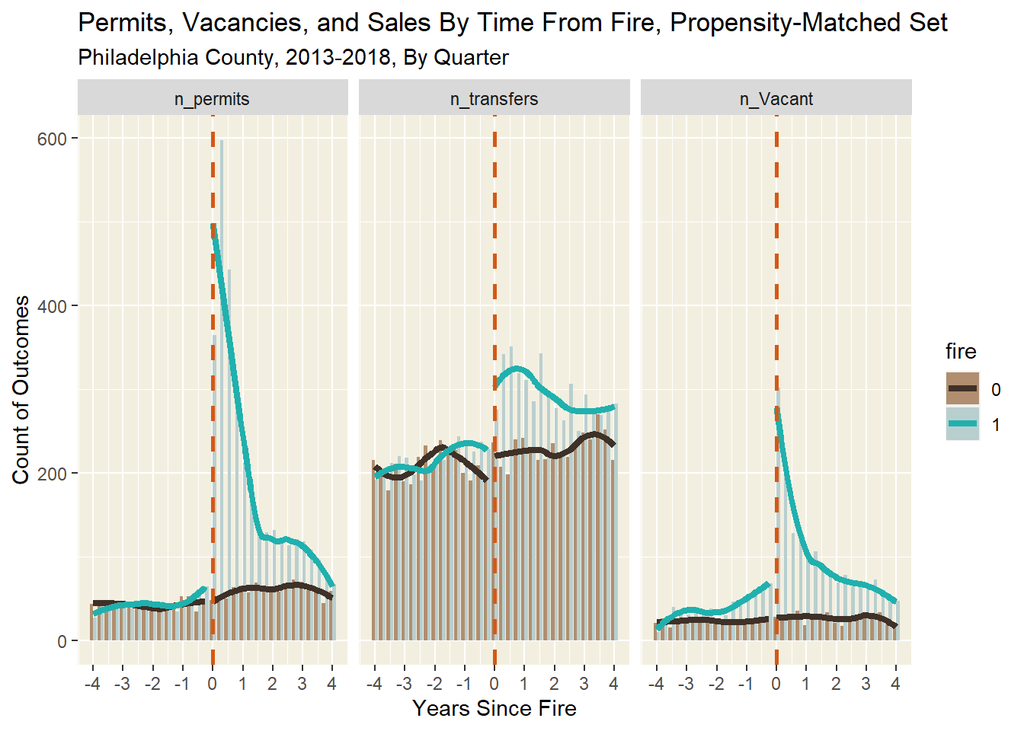

```r
#Distribution of Outcomes, Measuring Time between Fire and Outcome
panel_pm_4Y%>%
  filter(year(quarter.y) < 2019 & year(quarter.y) > 2012)%>%
  st_drop_geometry%>%
  ungroup()%>%
  filter(!(n_Vacant == 0 & n_permits == 0 & n_transfers == 0))%>%
  dplyr::select(n_transfers, n_Vacant, n_permits, ySinceFire, fire)%>%
  gather(Variable, value, -ySinceFire, -fire)%>%
  filter(value > 0)%>%
    count(ySinceFire, fire, Variable)%>%
  ggplot(aes(x=ySinceFire, y=n, fill=fire))+
    geom_col(position="dodge", just = 0.5)+
      labs(title="Permits, Vacancies, and Sales By Time From Fire, Propensity-Matched Set",
       subtitle="Philadelphia County, 2013-2018, By Quarter")+
      geom_smooth(se=FALSE, aes(color = fire, group = paste(fire, (ySinceFire >= 0))), size = 1.5)+
  facet_wrap(~Variable) +
  xlab("Years Since Fire")+
  ylab("Count of Outcomes")+
  scale_x_continuous(breaks = c(-4, -3, -2, -1, 0, 1, 2, 3, 4))+
    theme(panel.background = element_rect(fill = "#f3efe0"))+
  scale_fill_manual(values = c("#b18e6f", "#b9cfcf"))+
  scale_color_manual(values = c("#3f3128", "#20b1ae"))+
  geom_vline(xintercept = 0, color = "#d55816", size = 1, linetype = "dashed")
```

## Are investors buying fire-stricken properties at a higher rate than normal properties?

With our case study featuring two examples of investor-purchased homes, we were curious if this was a larger trend. In short, the transfer of properties between investors and homeowners is a minority of property transfers as a whole, but fires do affect sales in these categories in two different ways.

```r
transfers <- read_csv("../Data/OpenDataPhilly-transfers.csv")

#Select relevant fields and filter to fire data range
transfers_data <- transfers%>%
  dplyr:: select(objectid, recording_date, street_address, document_type, grantors, grantees)%>%
  filter(year(recording_date) > 2008,
         !is.na(street_address))%>%
  rename(address = street_address)%>%
  mutate(quarter = as_date(floor_date(recording_date, unit="quarter")))
```

We’re defining investors as those who own above 5 properties in the OPA dataset and those that have ‘LLC’, ‘LP’, ‘REO’, ‘Investments’, ‘Homes’, ‘Trust’, ‘Corp’, ‘Inc’ in their name. From this criteria, we created a list of investors to find in the matched set.

```r
toMatch <- c('LLC', 'LP', 'REO', 'Investments', 'Homes', 'Trust', 'Corp', 'Inc')

investors <- unique(grep(paste(toMatch,collapse="|"),
                        transfers_data$grantees, value=TRUE))

#Check for owners with 5+ properties
investors_opa <- opa_dat%>%
  st_drop_geometry()%>%
  dplyr::select(owner_1)%>%
  group_by(owner_1)%>%
  filter(n()>5)

investors_list_opa <- unique(investors_opa)

transfers_data <- transfers_data%>%
  mutate(investorBuy = ifelse(grantees %in% investors | grantees %in% investors_list_opa, TRUE, FALSE),
         investorSell = ifelse(grantors %in% investors | grantors %in% investors_list_opa, TRUE, FALSE))%>%
  mutate(homeownerToInvestor = ifelse(investorBuy == TRUE & investorSell== FALSE, TRUE, FALSE),
         investorToHomeowner = ifelse(investorSell == TRUE & investorBuy== FALSE, TRUE, FALSE))

#join transfers data to property by address and quarter

panel_pm_4Y_sales <- panel_pm_4Y%>%
  rename(quarter = quarter.x)%>%
  left_join(dplyr::select(transfers_data, address, quarter, homeownerToInvestor, investorToHomeowner), by=c("address", "quarter"))
```

### Homeowner to investor, investor to homeowner

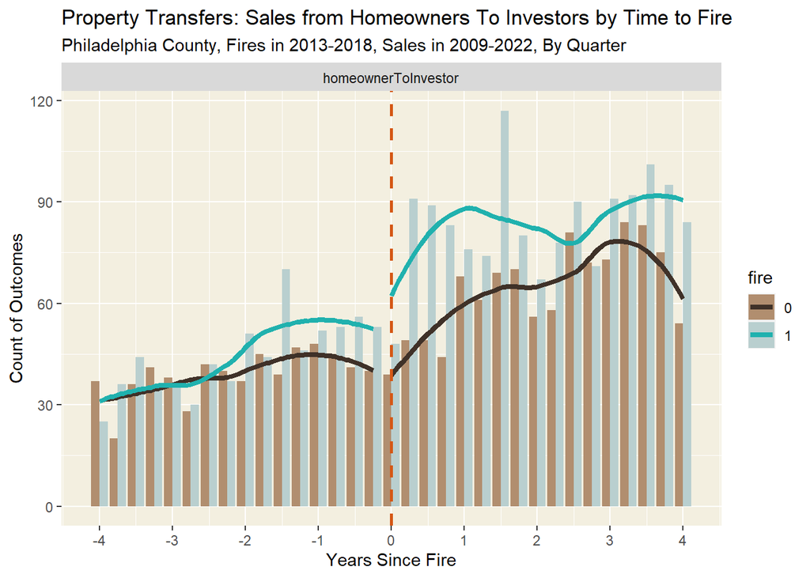

```r
panel_pm_4Y_sales%>%
  filter(year(quarter.y) < 2019 & year(quarter.y) > 2012)%>%
  st_drop_geometry%>%
  ungroup()%>%
  filter(!(n_transfers == 0))%>%
  dplyr::select(ySinceFire, fire, homeownerToInvestor)%>%
  gather(Variable, value, -ySinceFire, -fire)%>%
  filter(value == TRUE)%>%
    count(ySinceFire, fire, Variable)%>%
  ggplot(aes(x=ySinceFire, y=n, fill=fire))+
    geom_col(position="dodge", just = 0.5)+
      labs(title="Property Transfers: Sales from Homeowners To Investors by Time to Fire",
       subtitle="Philadelphia County, Fires in 2013-2018, Sales in 2009-2022, By Quarter")+
      geom_smooth(se=FALSE, aes(color = fire, group = paste(fire, (ySinceFire >= 0))), size = 1.5)+
  facet_wrap(~Variable) +
  xlab("Years Since Fire")+
  ylab("Count of Outcomes")+
  scale_x_continuous(breaks = c(-4, -3, -2, -1, 0, 1, 2, 3, 4))+
    theme(panel.background = element_rect(fill = "#f3efe0"))+
  scale_fill_manual(values = c("#b18e6f", "#b9cfcf"))+
  scale_color_manual(values = c("#3f3128", "#20b1ae"))+
  geom_vline(xintercept = 0, color = "#d55816", size = 1, linetype = "dashed")
```

Conversely, if we look at investor-to-homeowner sales, there’s a lag time where investor-owned properties with fires are sold at a lower rate, but then investor sales pick up after six months. This may indicate a flip-sale trend, with a purchase and renovation period in the couple quarters, followed by increased sales from the investors.

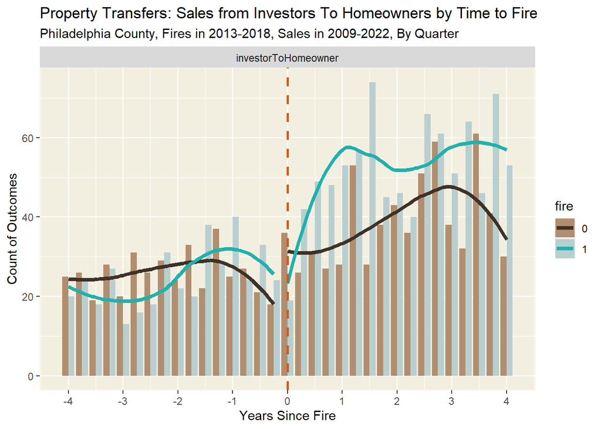

```r
panel_pm_4Y_sales%>%
  filter(year(quarter.y) < 2019 & year(quarter.y) > 2012)%>%
  st_drop_geometry%>%
  ungroup()%>%
  filter(!(n_transfers == 0))%>%
  dplyr::select(ySinceFire, fire, investorToHomeowner)%>%
  gather(Variable, value, -ySinceFire, -fire)%>%
  filter(value == TRUE)%>%
    count(ySinceFire, fire, Variable)%>%
  ggplot(aes(x=ySinceFire, y=n, fill=fire))+
    geom_col(position="dodge", just = 0.5)+
      labs(title="Property Transfers: Sales from Investors To Homeowners by Time to Fire",
       subtitle="Philadelphia County, Fires in 2013-2018, Sales in 2009-2022, By Quarter")+
      geom_smooth(se=FALSE, aes(color = fire, group = paste(fire, (ySinceFire >= 0))), size = 1.5)+
  facet_wrap(~Variable) +
  xlab("Years Since Fire")+
  ylab("Count of Outcomes")+
  scale_x_continuous(breaks = c(-4, -3, -2, -1, 0, 1, 2, 3, 4))+
    theme(panel.background = element_rect(fill = "#f3efe0"))+
  scale_fill_manual(values = c("#b18e6f", "#b9cfcf"))+
  scale_color_manual(values = c("#3f3128", "#20b1ae"))+
  geom_vline(xintercept = 0, color = "#d55816", size = 1, linetype = "dashed")
```